# Untitled

Firstly we should load dplyr package, it’ll help us to manage datasets in more convenient way.

```r
library(dplyr)
```

Let’s read our table.

```r
info <- tbl_df(read.csv("activity.csv"))
```

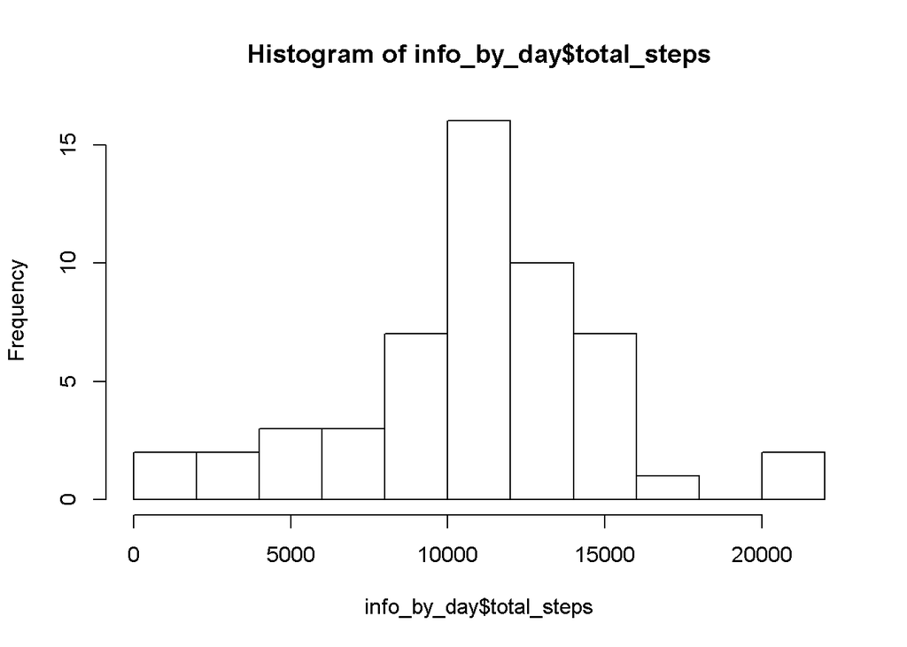

```r
info_grouped_by_day <- group_by(info, date)
info_by_day <- summarise(info_grouped_by_day, total_steps = sum(steps),
      average_steps = mean(steps, na.rm = TRUE, median_steps = median(steps)))

hist(info_by_day$total_steps, breaks = 10)
```

We’ve done great work! Let’s continue!

So now it’ll be good to group main dataframe by time, and create new dataframe with useful information.

```r
info_grouped_by_time <- group_by(info, interval)
info_by_time <- summarise(info_grouped_by_time,
      average_steps = mean(steps, na.rm = TRUE))
```

We’ve accomplished that! Let’s now create a plot with ggplot2 package, so our plot will be aesthetical and informative.

So we need to load ggplot2 package.

```r
library(ggplot2)
```

Let’s start the analysis.

```r
head(info_by_time)
```

```
## Source: local data frame [6 x 2]
##
##   interval average_steps
##      (int)         (dbl)
## 1        0     1.7169811
## 2        5     0.3396226
## 3       10     0.1320755
## 4       15     0.1509434
## 5       20     0.0754717
## 6       25     2.0943396
```

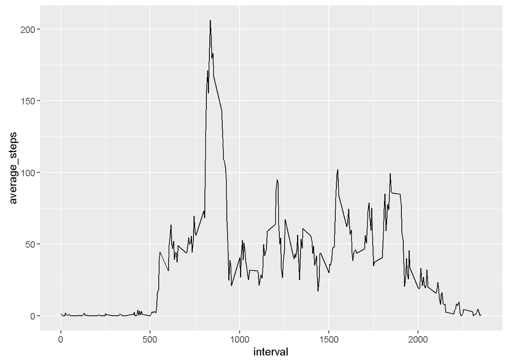

```r
time_plot <- ggplot(info_by_time, aes(interval, average_steps))
time_plot + geom_line()
```

```r
info_by_time[which.max(info_by_time$average_steps), ]
```

```
## Source: local data frame [1 x 2]
##
##   interval average_steps
##      (int)         (dbl)
## 1      835      206.1698
```

Now let’s deal with NAs in our dataset. Firstly, I consider we should calculate total number of missing values in our dataframe.

```r
sum(is.na(info))
```

```
## [1] 2304
```

```r
head(info_by_time)
```

```
## Source: local data frame [6 x 2]
##
##   interval average_steps
##      (int)         (dbl)
## 1        0     1.7169811
## 2        5     0.3396226
## 3       10     0.1320755
## 4       15     0.1509434
## 5       20     0.0754717
## 6       25     2.0943396
```

```r
NAs <- which(is.na(info$steps))
for (i in NAs) {
      NA_interval <- info[i, "interval"]
      NA_interval <- NA_interval[[1]]

      average_steps_for_this_interval <-
            filter(info_by_time, interval == NA_interval)$average_steps

      info[i, "steps"] = average_steps_for_this_interval
            + rnorm(1, mean = 1, sd = 0.3)
}

head(info)
```

```
## Source: local data frame [6 x 3]
##
##       steps       date interval
##       (dbl)     (fctr)    (int)
## 1 1.7169811 2012-10-01        0
## 2 0.3396226 2012-10-01        5
## 3 0.1320755 2012-10-01       10
## 4 0.1509434 2012-10-01       15
## 5 0.0754717 2012-10-01       20
## 6 2.0943396 2012-10-01       25
```

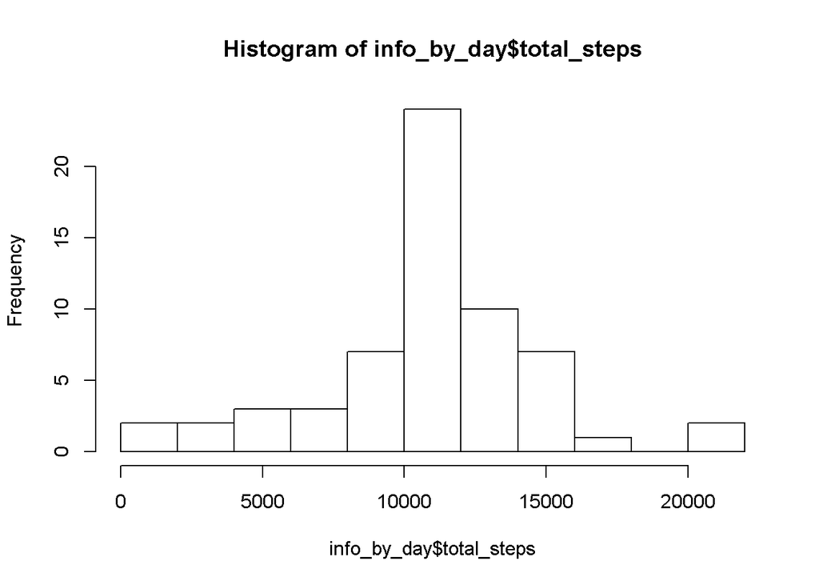

```r
info_grouped_by_day <- group_by(info, date)
info_by_day <- summarise(info_grouped_by_day, total_steps = sum(steps),
      average_steps = mean(steps, na.rm = TRUE, median_steps = median(steps)))

hist(info_by_day$total_steps, breaks = 10)
```

I think that we should search for interesting information in dates of observations. Let’s divide our dataset into 2 parts. First will include weekday and second - weekends.

```r
library(lubridate)
info <- mutate(info, weekday = wday(as.POSIXlt(date)),
      type_of_day = factor(ifelse(weekday == 1 | weekday == 7, "Weekend",
            "Weekday")), wd = weekdays(as.POSIXlt(date)))

head(filter(info, weekday == 1))
```

```
## Source: local data frame [6 x 6]
##
##   steps       date interval weekday type_of_day     wd
##   (dbl)     (fctr)    (int)   (dbl)      (fctr)  (chr)
## 1     0 2012-10-07        0       1     Weekend Sunday
## 2     0 2012-10-07        5       1     Weekend Sunday
## 3     0 2012-10-07       10       1     Weekend Sunday
## 4     0 2012-10-07       15       1     Weekend Sunday
## 5     0 2012-10-07       20       1     Weekend Sunday
## 6     0 2012-10-07       25       1     Weekend Sunday
```